# X-brain

## INBOX

See which genes share GO:0031175 (neuron projection development) and GOs for spermatogenesis

Are ASD genes enriched for Xi genes?

Could NLGN4Y be an example of a gene adapted to drive in spermatogenesis, with detrimental effects in male brain when there is not a functioning NLGN4X to compelsate? It is at least an example of a both an XI escaper and a gametolog

NLGN4Y is related to testis mas in Mikkel’s sex chrom paper

Overlap between neuronal migration, sperm motility, and meiotic spindle

Only miRNA escape MSCI some mRNA post meiotic silencing

## Jakob’s MAGMA pilot

In a pilot study of ASD GWAS iPsych GWAS summary statistics (MAGMA), separately analyzing males and females to avoid confounding sex-specific effects, we find the following positive associations with ASD risk:

- **Xi escape** genes in **males** (p-value: 0.027, beta: 0.03 )
- **Gametologs** in **females** (p-value: 0.026, beta: 0.45)
- **Neuron+spermatid** genes in **males** (p-value: 0.030, beta: 0.14) (All neuron genes not)

**NB:** Note the strange observation that ECH regions seem to be “protective” against ASD:

- non-PAR X genes (NPX) show no association, but when subtracting ECH-genes (NPX-OvHuSw), the association is almost significant (p-value: 0.059) with a beta of 0.17.

## Other enrichments

- In a standard GO analysis of neuron+spermatid genes vs all neuron genes, we find a significant 44% enrichment of “cytosol genes” and “extracellular exosome genes” are twice as frequent in neuron+spermatid as in neuron genes. Chromatin genes are completely absent in neuron+spermatid
- These neuron+spermatid cytosol genes are enriched for both xi-escapers and deltaE genes.
- XCI among cytosol enriched: {‘DDX3X’, ‘EIF2S3’, ‘HUWE1’, ‘RAB9A’, ‘RPS4X’, ‘SYAP1’, ‘UBA1’}
- deltaE among cytosol enriched: {‘DDX3X’, ‘EIF1AX’, ‘FMR1’, ‘GDI1’, ‘GRIPAP1’, ‘PUDP’, ‘RBBP7’, ‘SMC1A’, ‘SYAP1’, ‘TBC1D8B’, ‘TMSB4X’, ‘UBA1’}
- iPsych found TSPAN7 and SLC25A14 genes.

## Doug’s analysis

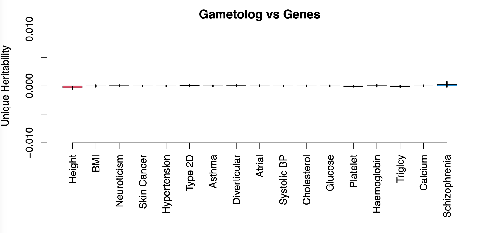

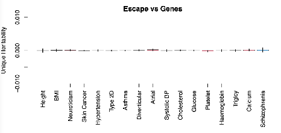

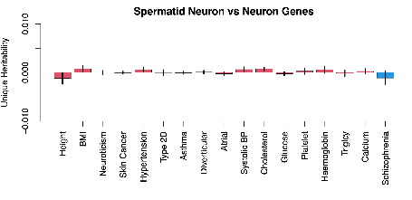

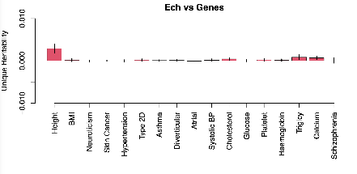

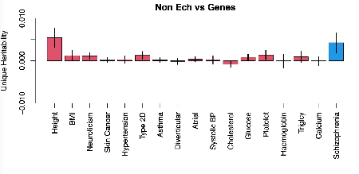

**NB:** In the last analysis, Doug also observes that non-ECH genes explain significant unique heritability compared to the full set of genes. I.e. leaving out the 10% of the genome that ECHs represent somehow produces this signal?

## Ari’s selection scan

Relate on 1000g populations: CDX CHB CHS ESN FIN GBR GWD IBS JPT KHV LWK MSL PUR TSI YRI. Selection on protein-coding X genes overlapping a SNP with Relate -log10 p-value above 6 (I.e., multiple correction for chrX testing only):

- **Among *brain-expressed* genes, ASD genes are enriched for genes also expressed in spermatids** (p-value: 0.0012). This property may just characterize ASD genes as pleiotropic ”motor genes,” but it may also result from an ascertainment bias of ASD genes if the tissue sharing and drive that has promoted variants are detected as ASD genes.
- **Among *all* X genes, positively selected genes are enriched for ASD genes** (p-value: 5.9e-05).
- **Among *brain-expressed* genes, positively selected genes are enriched for genes expressed in spermatids** (p-value: 0.0019).
- Among *ASD* genes only, positively selected genes are not significantly enriched for genes expressed in spermatids - *although all 9 of them are*.

12 of 23 genes she finds are associated with either

- **ASD (bold)**
- *intellectual disability (italics)*
- *and/or seizures or speech impairment: (underlined)*
- No assocation
- Spermatid expression

*ACSL4* *BCOR* *CASK* *CDKL5* *CLCN4* *FRMPD4* G6PD GNL3L *HUWE1* *IGSF1* *IL1RAPL1* *MAGT1* MAMLD1 NYX PASD1 PHKA1 PRKX *PTCHD1* RAB33A TMEM164 **TMLHE** ZMYM3 ZNF185

Also finds these non-protein-coding genes:  
LINC01278 LINC01278 LOC101928359 LOC105377212 LOC112268307 LOC124905191 MIR325HG RAP2C-AS1

(See also [Gene sets](https://docs.google.com/spreadsheets/d/1JSjSLuto3jqdEnnG7JqzeC_1pUZw76n7XueVAYrUOpk/edit?gid=0#gid=0))

## Shannon’s offspring ratio distortion

Significant SNPs across the 88-95Mb region roughly match the region translocated to Y in humans.

- Is it driven by PCDH11X, TGIF2LX, or both?
- It might be the entire region if the Y inversion (or a new similar one) is segregating.

The translocation would have introduced a lot of selective pressure on dosage compensation males. There would be strong selection to resolve this by evolving separate (possibly sex-antagonistic) functions or expressions for the translocated genes. The gametolog property may have allowed them to evolve into drivers. Most of the region later inverted on Y, truncating TGIF2LY, but this is still expressed. I am not sure anyone knows if the Y inversion could still be segregating in humans. If the inversion happened once, it might also be recurrent.

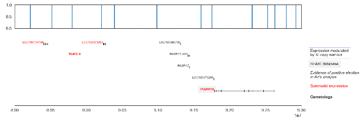

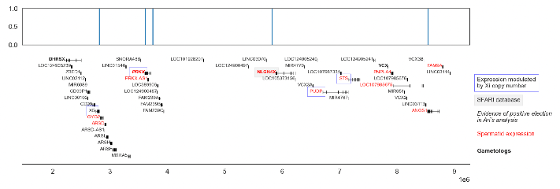

The SNPs in the 89-93Mb region seem to spread in a way that suggests it is the inversion itself that triggers ORD, maybe through an effect on chromatin domain structure. **ASK FOR AURORA’S HUMAN HIGH-C MAPS OR HAVE HER LOOK AT THEM**

**LOOK AT MERITXELL’S EXPRESSION TRAJECTORIES FOR SHANNON’S ORD SNPS**

PCDH11X, NLGN4X, and PRKX are all spermatid expressed and relatively recent gametologs (PCDH11X translocated in humans and PRKX, PRKX stratum 5, NLGN4X stratum 4). PCDH11X, NLGN4X are important ASD brain genes. PRKX is under selection and is a Xi copy number modulator.

“A Cluster of Autism-Associated Variantson X-Linked NLGN4X Functionally Resemble NLGN4Y” [(Nguyen 2020)](https://app.readcube.com/library/ff394a98-20f7-4882-871c-840e9f73d65b/all?uuid=5376235404428003&item_ids=ff394a98-20f7-4882-871c-840e9f73d65b:15d12e17-3943-4de4-9634-e13ea4b1fc50)

“Gene Conversion between the X Chromosome and the Male-Specific Region of the Y Chromosome at a Translocation Hotspot” [(Rosser 2009)](https://app.readcube.com/library/ff394a98-20f7-4882-871c-840e9f73d65b/all?uuid=47729410426760754&item_ids=ff394a98-20f7-4882-871c-840e9f73d65b:ee3aeff2-fa0a-40ac-9aab-e334c8ef136a)

“Spatial sexual dimorphism of X and Yhomolog gene expression in the human central nervous system during early male development” [(Johansson 2016)](https://app.readcube.com/library/ff394a98-20f7-4882-871c-840e9f73d65b/all?uuid=31921288966441475&item_ids=ff394a98-20f7-4882-871c-840e9f73d65b:12a85ff0-9bc3-410f-b9f6-43f49a5170cc)

“The protocadherin 11X/Y (PCDH11X/Y ) gene pairs determinant of cerebral asymmetry in modern Homo sapiens” [(Priddle 2013)](https://app.readcube.com/library/ff394a98-20f7-4882-871c-840e9f73d65b/all?uuid=06758496440892114&item_ids=ff394a98-20f7-4882-871c-840e9f73d65b:ccb552d7-e824-41e5-8750-ca447c09e3e3)

Xp22.3 deletion gives both mental retardation and infertility  
“Xp22.3 interstitial deletion: a recognizable chromosomal abnormality encompassing VCX3A and STS genes in a patient with X-linked ichthyosis and mental retardation”, “Novel interstitial deletion in Xp22.3 in a typical X-linked recessive family with Kallmann syndrome”

This is fun: “Male homosexuality and maternal immune responsivity to the Y-linked protein NLGN4Y” but I think [(Nguyen 2020)](https://app.readcube.com/library/ff394a98-20f7-4882-871c-840e9f73d65b/all?uuid=5376235404428003&item_ids=ff394a98-20f7-4882-871c-840e9f73d65b:15d12e17-3943-4de4-9634-e13ea4b1fc50) found that the dysfunction of NLGN4Y did not relate to its interaction with neurexin.

## MSCI-Xi hypothesis

Male meiotic sex-chromosome inactivation (MSCI), which limits the scope for meiotic drive in spermatogenesis, and somatic X chromosome inactivation (XCI), which inactivates the extra X in females, most likely evolved from the same highly conserved mechanism of un-synapsed chromatin silencing [(Hornecker et al. 2007)](https://app.readcube.com/library/ff394a98-20f7-4882-871c-840e9f73d65b/all?uuid=5194070555024363&item_ids=ff394a98-20f7-4882-871c-840e9f73d65b:0a632c11-eafb-4909-92fd-1b6159186ac2) and thus overlap in their control and chromatin organization. I hypothesize that meiotic drivers, in addition to other detrimental effects, fuel an inactivation-dosage-conflict between the sexes: If genes that escape MSCI in males also escape XCI in females, the deleterious excess female dosage must be resolved by lower gene expression, in turn leading to dosage deficiency in males (Figure below). Jakob’s MAGMA pilot seems to comfort the hypothesis’ two predictions:

1. ASD association in males is enriched among genes escaping female XCI.
2. ASD association in females is enriched among gametologs (candidate meiotic driver genes with a homolog on the Y chromosome).

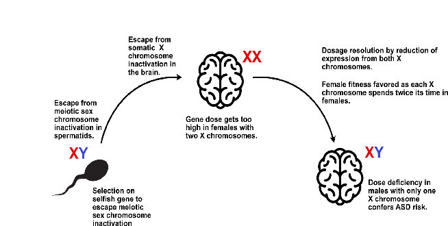

## Hitchhiking hypothesis

ASD risk-variants “hitchhike” to a higher frequency with genes under strong selection or sperm function.

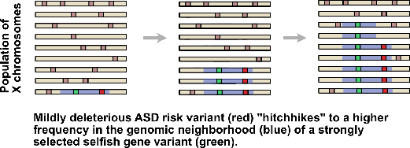

## Chromatin structure hypothesis

Super-loops established by CTCF binding at the XIST, FIRRE, and DXZ4 loci are crucial to proper X inactivation. However, new results show that DXZ4 is also a speciation gene in cats responsible for infertility in hybrid males through its effect on MSCI. Genes with such dual roles in Xi and MSCI suggest that strong selection for genes to escape MSCI may affect or, in some cases, even determine whether the same genes escape Xi. Drivers at the edges of suppressed heterochromatin domains may be exposed if the X is paired with a Y with a repeat composition draining chromatin-maintaining genes. Drivers may also modify chromatin to control their expression by increasing ampliconic gene copy number or by modifying linked euchromatin-insulating CTFC tandem repeat motifs [(Giorgetti et al. 2016)](https://app.readcube.com/library/ff394a98-20f7-4882-871c-840e9f73d65b/all?uuid=32593301411294096&item_ids=ff394a98-20f7-4882-871c-840e9f73d65b:5cb609ae-e29a-40d8-9c9d-cac81f058593).

See also notes in [Heterochromatin / chrom synteny](https://docs.google.com/document/d/158mIGnCOQxHB8zgfKfSmn2we5re8PwiU_lsdhwUphzs/edit#heading=h.2yiapkr8vck9).

## TODOs

- QC X SNP chip data (~80,000 cases / ~50,000 controls)
- QC Y SNP chip data (~80,000 cases / ~50,000 controls)
- QC X exome data (~10,000 cases / ~10,000 controls)

## Approaches

- X data quality control: Curate and filter base calling and imputation in iPSYCH chrX data.
- Method development: Extend ARG-needle and LDAK software to accommodate different numbers of chrX in males and females and the gene-by-gene XCI status in females.
- GWAS on X
- Assign y-haplotype to each male and use that as in an interaction model to see if it is the interaction between X variants and particular Y haplotypes that generate the ASD phenotype.
- LDSC or interaction-LDSC on X.
- Apply MAGMA gene-wise and gene-set analyses (works out of the box on X)
- Tissue/sex conflict: Generate PGS and heritability using a modified ARGneedle or LDAK. Use multivariate multivariable PGS regression on gene sets to evaluate ASD risk and heritability explained by the following gene properties: XCI escape, MSCI escape, gametolog on Y, evolutionary stratum, chromatin compartment localization, promoter methylation, spermatid vs spermatozoa expression, brain region expression.
- Impact of sex: Include sex and ICD-10 ASD subtypes in PGS regression to evaluate whether different gene sets dominate their ASD risk.
- Hitchhiking risk variants: Use RELATE and CLUES software to compute the likelihood ratio of positive selection at each SNP. Then, include this in PGS regressions to evaluate the expected positive correlation between LR and risk-allele frequency. How does risk score relate to frequency on the X compared to autosomes? Are the frequencies higher on X for the same risk?
- Pooling iPSYCH data with unexploited X chromosome data from the ASD cohorts of PGC and SPARK and testing if X-Y interaction contributes to ASD by assigning cohort individuals to Y haplogroups.
- Mechanistic insights: Using publicly available gene ontology and protein-protein interaction information, identify pathways responsible for higher ASD load among gene sets.
- Detailed investigations of candidate mechanisms unique to chrX.

## References

Giorgetti L, Lajoie BR, Carter AC, Attia M, Zhan Y, et al. 2016. Structural organization of the inactive X chromosome in the mouse. *Nature*. 535(7613):575–79  
Hornecker JL, Samollow PB, Robinson ES, VandeBerg JL, McCarrey JR. 2007. Meiotic sex chromosome inactivation in the marsupial Monodelphis domestica. *genesis*. 45(11):696–708  
Zhang BC, Biddanda A, Gunnarsson ÁF, Cooper F, Palamara PF. 2023. Biobank-scale inference of ancestral recombination graphs enables genealogical analysis of complex traits. *Nat. Genet.* 55(5):768–76